# MLBD / Lab 2 / Features extraction

After you have evaluated your model **write a short analysis of your results**.

```python
# MLBD - Labo

# 1) Compute eccentricity for all images in the dataset
#------------------------------------------------------
def compute_eccentricity_vector():

    nb_images = len(meta.iloc[:])

    eccentricity_vector = np.zeros((nb_images,))

    for i in range(0, nb_images):
        img = load_img(meta.iloc[i]['basename'])
        eccentricity_vector[i] = eccentricity(img, plot=False)

    return eccentricity_vector

# 2) Compute curv
#------------------------------------------------------
# nbins and vmax : number of bins in the histogram and range of the bins [0, vmax] .
def compute_curv_vector(N_BINS, MAX_V):

    nb_images = len(meta.iloc[:])

    curv_vector = np.empty(shape=(nb_images, N_BINS))

    for i in range(0, nb_images):
        img = load_img(meta.iloc[i]['basename'])
        curv_vector[i] = np.array(curvature_hist(img, N_BINS, MAX_V, step=10, plot=False)) #np.random.randint(vmax, size=nbins)

    return curv_vector

# 3) Compute ...
#------------------------------------------------------
def compute_new_vector():

    nb_images = len(meta.iloc[:])

    new_vector = np.empty(shape=(nb_images, 1))

    for i in range(0, nb_images):
        img = load_img(meta.iloc[i]['basename'])
        new_vector[i] = Ratio_Convex(img)

    return new_vector
```

```python
# Normalizing your data.
# sklearn.preprocessing.MinMaxScaler might be useful (or other similar scaler classes)
#-------------------------------------------------------------------------------------
#TODO : Check correctness
def numpy_minmax(X):
    xmin =  X.min(axis=0)
    return (X - xmin) / (X.max(axis=0) - xmin)
```

```python
# MLBD - Labo

def test_kNN(X, k):

    # Build a n x m data matrix X with the feature vectors of all the images,
    # where n is the number of images and m the number of features.
    #------------------------------------------------------------------------
    print "Dataset X ", X.shape

    # Build an integer vector of length n, y, containing the target class for each image.
    # sklearn.preprocessing.LabelEncoder is useful for converting text labels into integers.
    #----------------------------------------------------------------------------------------
    y = np.array(meta.iloc[:]['classid'])

    # Replace classid by integer with sklearn.preprocessing.LabelEncoder
    class_label = np.unique(meta.iloc[:]['classid']) # Get labels

    from sklearn import preprocessing
    lencoder = preprocessing.LabelEncoder()
    lencoder.fit(class_label)

    # Replce classid by integer
    y = lencoder.transform(y)

    print "Dataset Y ", y.shape

    # Normalizing your data.
    # sklearn.preprocessing.MinMaxScaler might be useful (or other similar scaler classes)
    #-------------------------------------------------------------------------------------
    X = numpy_minmax(X) # TODO : Check correctness


    # Split your dataset into training and test : X_train, X_test, y_train, y_test.
    # sklearn.model_selection has useful utility functions for that.
    # -----------------------------------------------------------------------------
    from sklearn import cross_validation

    # train and test are indices arrays containing the indices of train/test samples
    train, test = cross_validation.train_test_split(

        # we fix random state for reproducibility)
        np.arange(X.shape[0]), test_size=0.4, random_state=42
    )

    print "train shape : ", train.shape
    print "test shape  : ", test.shape

    X_train = X[train]
    y_train = y[train]
    X_test = X[test]
    y_test = y[test]

    #
    # Fit the KNN model here
    #
    print " ------------------------------------------------------------------------------ "

    # Build a classifier with sklearn.neighbors.KNeighborsClassifier
    # on your training dataset and evaluate on your test dataset.
    #
    # this needs to be done before executing the *y_pred = knn.predict(X_test)* cell
    # ------------------------------------------------------------------------------

    from sklearn.neighbors import KNeighborsClassifier

    knn = KNeighborsClassifier(n_neighbors=k)

    knn.fit(X_train, y_train)

    y_pred = knn.predict(X_test)

    # performance evaluation
    import sklearn.metrics as skmetrics
    from sklearn.metrics import confusion_matrix

    report = skmetrics.classification_report(y_test, y_pred,
                                             labels=np.arange(len(lencoder.classes_)),
                                             target_names=lencoder.classes_)

    confmat = confusion_matrix(y_test, y_pred)

    pl.figure(figsize=(10, 10))
    plot_confusion_matrix(confmat, lencoder.classes_, cmap=cm.gray_r)

    print report
```

```python
def plot_confusion_matrix(confmat, labels_names, ax=None, cmap=None):
    """Utility function to plot a confusion matrix"""
    if ax is None:
        ax = pl.subplot(111)
    cmim = ax.matshow(confmat, interpolation='nearest', cmap=cmap)

    for i in xrange(confmat.shape[0]):
        for j in xrange(confmat.shape[1]):
            ax.annotate(str(confmat[i, j]), xy=(j, i),
                        horizontalalignment='center',
                        verticalalignment='center',
                        fontsize=8)
    ax.set_xticks(np.arange(confmat.shape[0]))
    ax.set_xticklabels([labels_names[l] for l in xrange(confmat.shape[0])], rotation='vertical')
    ax.set_yticks(np.arange(confmat.shape[1]))
    _ = ax.set_yticklabels([labels_names[l] for l in xrange(confmat.shape[1])])
    ax.set_xlabel('predicted label')
    ax.xaxis.set_label_position('top')
    ax.set_ylabel('true label')
    pl.colorbar(cmim, shrink=0.7, orientation='horizontal', pad=0.01)
```

```python
# MLBD - Labo

# Compute the feature vector of each image (by concatenating individual features of the image).
# --------------------------------------------------------------------------------------------
eccentricity_vector = compute_eccentricity_vector()
new_vector = compute_new_vector()
N_BINS = 3
MAX_V = 0.3
curv_vector = compute_curv_vector(N_BINS, MAX_V)
```

```python
nb_images = len(meta.iloc[:])
```

```
Dataset X  (583, 1)
Dataset Y  (583,)
train shape :  (349,)
test shape  :  (234,)
 ------------------------------------------------------------------------------
```

```
                         precision    recall  f1-score   support

         acer campestre       0.47      0.56      0.51        25
    ailanthus altissima       0.43      0.40      0.41        30
        alnus glutinosa       0.22      0.17      0.19        12
          arbutus unedo       0.37      0.48      0.42        33
        castanea sativa       0.40      0.26      0.31        31
liquidambar styraciflua       0.14      0.09      0.11        11
        nerium oleander       0.95      1.00      0.97        38
      quercus pubescens       0.41      0.57      0.47        23
     vitex agnus-castus       0.44      0.35      0.39        31

            avg / total       0.48      0.49      0.48       234
```

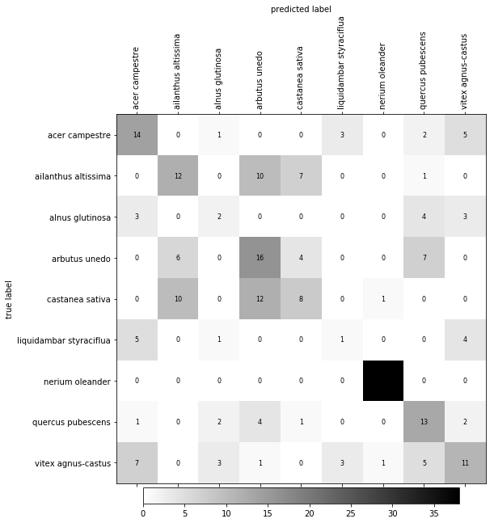

```python
X = eccentricity_vector.reshape((nb_images, 1))
k = 1
test_kNN(X, k)
```

```
Dataset X  (583, 5)
Dataset Y  (583,)
train shape :  (349,)
test shape  :  (234,)
 ------------------------------------------------------------------------------
                         precision    recall  f1-score   support

         acer campestre       0.74      0.80      0.77        25
    ailanthus altissima       1.00      1.00      1.00        30
        alnus glutinosa       0.82      0.75      0.78        12
          arbutus unedo       0.94      0.88      0.91        33
        castanea sativa       0.88      0.90      0.89        31
liquidambar styraciflua       0.50      0.55      0.52        11
        nerium oleander       1.00      1.00      1.00        38
      quercus pubescens       0.87      0.87      0.87        23
     vitex agnus-castus       1.00      0.97      0.98        31

            avg / total       0.90      0.90      0.90       234
```

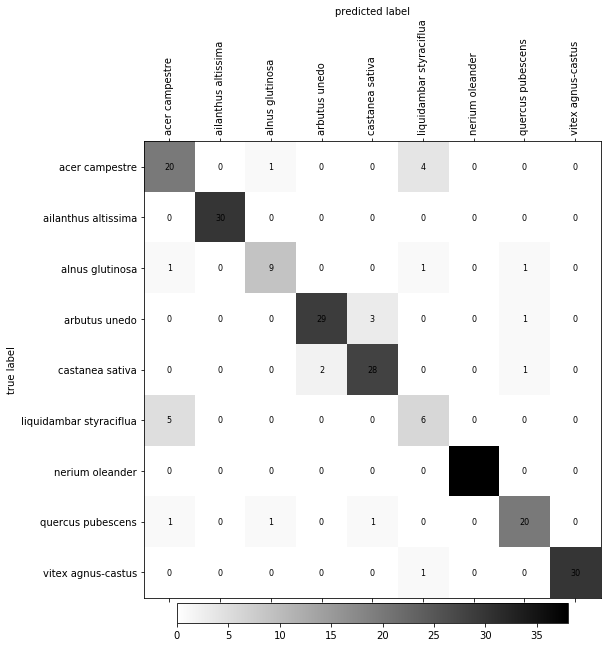

```python
X = eccentricity_vector.reshape((nb_images, 1))
X = np.append(X, curv_vector, axis=1)
X = np.append(X, new_vector, axis=1)
k = 1
test_kNN(X, k)
```

```
Dataset X  (583, 5)
Dataset Y  (583,)
train shape :  (349,)
test shape  :  (234,)
 ------------------------------------------------------------------------------
                         precision    recall  f1-score   support

         acer campestre       0.72      0.92      0.81        25
    ailanthus altissima       1.00      1.00      1.00        30
        alnus glutinosa       0.78      0.58      0.67        12
          arbutus unedo       0.86      0.91      0.88        33
        castanea sativa       0.93      0.84      0.88        31
liquidambar styraciflua       0.75      0.55      0.63        11
        nerium oleander       1.00      1.00      1.00        38
      quercus pubescens       0.83      0.87      0.85        23
     vitex agnus-castus       1.00      0.97      0.98        31

            avg / total       0.90      0.90      0.90       234
```

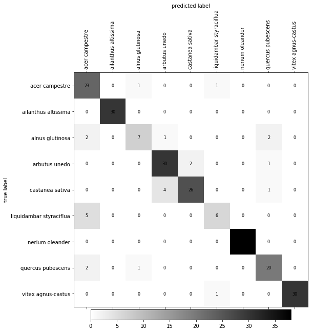

```python
X = eccentricity_vector.reshape((nb_images, 1))
X = np.append(X, curv_vector, axis=1)
X = np.append(X, new_vector, axis=1)
k = 3
test_kNN(X, k)
```

```
Dataset X  (583, 5)
Dataset Y  (583,)
train shape :  (349,)
test shape  :  (234,)
 ------------------------------------------------------------------------------
                         precision    recall  f1-score   support

         acer campestre       0.71      0.96      0.81        25
    ailanthus altissima       1.00      1.00      1.00        30
        alnus glutinosa       0.80      0.67      0.73        12
          arbutus unedo       0.79      0.94      0.86        33
        castanea sativa       0.92      0.74      0.82        31
liquidambar styraciflua       1.00      0.36      0.53        11
        nerium oleander       1.00      1.00      1.00        38
      quercus pubescens       0.91      0.91      0.91        23
     vitex agnus-castus       1.00      1.00      1.00        31

            avg / total       0.91      0.90      0.89       234
```

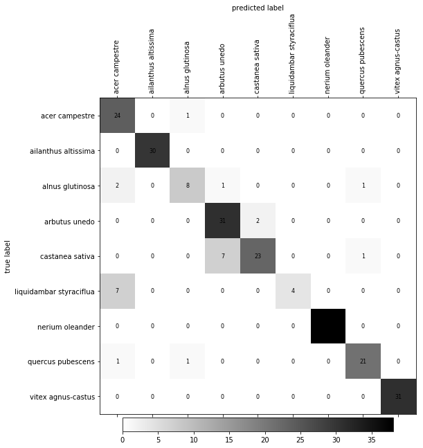

```python
X = eccentricity_vector.reshape((nb_images, 1))
X = np.append(X, curv_vector, axis=1)
X = np.append(X, new_vector, axis=1)
k = 5
test_kNN(X, k)
```

```
Dataset X  (583, 7)
Dataset Y  (583,)
train shape :  (349,)
test shape  :  (234,)
 ------------------------------------------------------------------------------
                         precision    recall  f1-score   support

         acer campestre       0.96      0.88      0.92        25
    ailanthus altissima       1.00      1.00      1.00        30
        alnus glutinosa       0.75      0.75      0.75        12
          arbutus unedo       0.88      0.91      0.90        33
        castanea sativa       0.91      0.94      0.92        31
liquidambar styraciflua       0.75      0.82      0.78        11
        nerium oleander       1.00      1.00      1.00        38
      quercus pubescens       0.91      0.87      0.89        23
     vitex agnus-castus       0.97      0.97      0.97        31

            avg / total       0.93      0.93      0.93       234
```

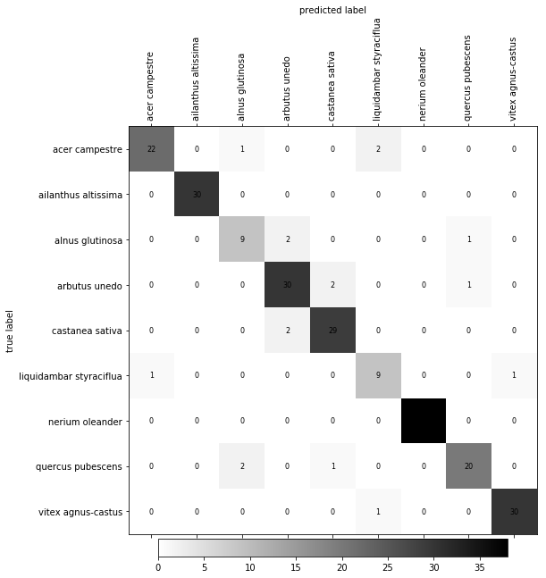

```python
N_BINS = 5
MAX_V = 0.3
curv_vector = compute_curv_vector(N_BINS, MAX_V)

X = eccentricity_vector.reshape((nb_images, 1))
X = np.append(X, curv_vector, axis=1)
X = np.append(X, new_vector, axis=1)
k = 1
test_kNN(X, k)
```

```
Dataset X  (583, 12)
Dataset Y  (583,)
train shape :  (349,)
test shape  :  (234,)
 ------------------------------------------------------------------------------
                         precision    recall  f1-score   support

         acer campestre       0.89      0.96      0.92        25
    ailanthus altissima       1.00      1.00      1.00        30
        alnus glutinosa       0.70      0.58      0.64        12
          arbutus unedo       0.85      0.85      0.85        33
        castanea sativa       0.96      0.87      0.92        31
liquidambar styraciflua       0.90      0.82      0.86        11
        nerium oleander       1.00      1.00      1.00        38
      quercus pubescens       0.77      0.87      0.82        23
     vitex agnus-castus       0.97      1.00      0.98        31

            avg / total       0.92      0.91      0.91       234
```

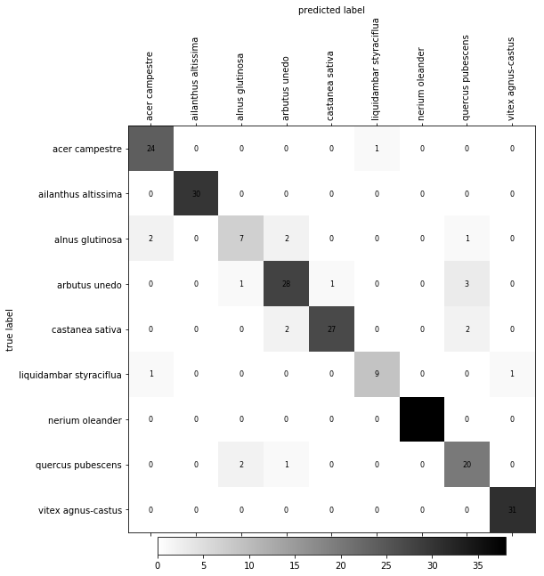

```python
N_BINS = 10
MAX_V = 0.3
curv_vector = compute_curv_vector(N_BINS, MAX_V)
curv_vector = compute_curv_vector(N_BINS, MAX_V)

X = eccentricity_vector.reshape((nb_images, 1))
X = np.append(X, curv_vector, axis=1)
X = np.append(X, new_vector, axis=1)
k = 1
test_kNN(X, k)
```

## Multilayer Perceptron with keras

**Keras** is a machine learning library that implements artificial neural networks. It has the advantage of allowing very compact and fast implementations of complex network architectures. **Keras** is a high level framework that uses one of two backends: **TensorFlow** or **Theano**. Whatever the choice, **Keras** allows to (transparently) compile python scripts into CPU or GPU code.

**Keras** can be easily installed by doing:

```
$ conda install keras
```

However, this basic installation does not provide GPU support for the **Tensorflow** backend.

**Keras** documentation can be found at https://keras.io/.

Q: Train a feed-forward neural network to perform plant species classification.

Prepare your data. Normalize the features you computed, transform the output data into binary vectors, split the data to create training a testing datasets. You will most likely need :

```
from sklearn import preprocessing as pp
from sklearn import model_selection as ms
```

To create your model, you will most likely need the following keras functions :

```
from keras.layers import Input, Dense
from keras.models import Model
from keras.optimizers import SGD
from keras.utils import np_utils
```

You have to build a network, then compile the model :

```
inputs = Input(shape=(N_FEATURES,))

hidden = Dense(N_NEURONS, activation='relu')(inputs)
outputs = Dense(N_OUTPUTS, activation='softmax')(hidden)

model = Model(input=inputs, output=outputs)
gradient_descent = SGD(lr=0.01, momentum=0.0, decay=0.0)

model.compile(optimizer=gradient_descent,
              loss='categorical_crossentropy',
              metrics=['accuracy'])
```

Then you have to train the model using the data you previously selected for training :

```
hist = model.fit(X_train, Y_train, validation_data=(X_test, Y_test), nb_epoch=10, batch_size=32)
```

To evaluate the performance of the model :

```
loss_and_metrics = model.evaluate(X_test, Y_test, batch_size=32)
```

And to run the model on new data :

```
probabilities = model.predict(X_test, batch_size=32)
```

At the end of training, show a plot with the test and train error vs. epochs.

```
pl.plot(hist.history['loss'])
pl.plot(hist.history['val_loss'])
```

Finally show a classification report and a confusion matrix.

```python
# MLBD - Labo
CNN_N_BINS = 5
CNN_MAX_V = 0.3
cnn_curv_vector = compute_curv_vector(CNN_N_BINS, CNN_MAX_V)
```

[output not shown]

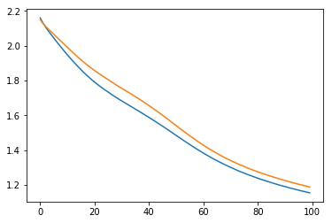

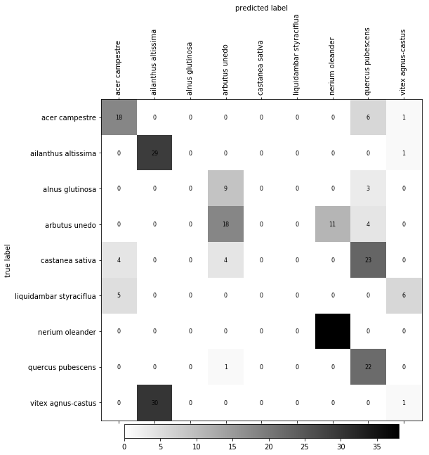

```python
# MLBD - Labo

# To create your model, you will most likely need the following keras functions :
from keras.layers import Input, Dense
from keras.models import Model
from keras.optimizers import SGD
from keras.utils import np_utils

from sklearn import preprocessing

import sklearn.metrics as skmetrics
from sklearn.metrics import confusion_matrix


# Prepare your data :
X = eccentricity_vector.reshape((nb_images, 1))

# Comment this line to do not use the feature
X = np.append(X, cnn_curv_vector, axis=1)

# Comment this line to do not use the feature
X = np.append(X, new_vector, axis=1)

# Replace classid by integer with sklearn.preprocessing.LabelEncoder
y = np.array(meta.iloc[:]['classid'])

class_label = np.unique(meta.iloc[:]['classid']) # Get labels
n_classes = class_label.shape[0]

lencoder = preprocessing.LabelEncoder()
lencoder.fit(class_label)

# Replace classid by integer
y = lencoder.transform(y)
y_labels = y # To print confusion matrix

# Normalize the features you computed,
# -----------------------------------------------------
# normalizer = preprocessing.Normalizer().fit(X) # fit does nothing
# X = normalizer.transform(X)

#TODO : Check correctness
def numpy_minmax(X):
    xmin =  X.min(axis=0)
    return (X - xmin) / (X.max(axis=0) - xmin)

X = numpy_minmax(X)

# transform the output data into binary vectors,
# -----------------------------------------------------
y = np_utils.to_categorical(y, n_classes)

# split the data to create training a testing datasets
# -----------------------------------------------------
from sklearn import cross_validation

# train and test are indices arrays containing the indices of train/test samples
train, test = cross_validation.train_test_split(

    # we fix random state for reproducibility)
    np.arange(X.shape[0]), test_size=0.4, random_state=42
)

print "train shape : ", train.shape
print "test shape  : ", test.shape

X_train = X[train]
Y_train = y[train]
X_test = X[test]
Y_test = y[test]

y_confmat = y_labels[test] # To print confusion matrix

print " ------------------------------------------------------------------------------ "
N_FEATURES = X.shape[1]
N_OUTPUTS = 9
N_NEURONS = 4

N_LEARNING_RATE = 0.05
N_MOMENTUM = 0.1

N_EPOCH = 100

# You have to build a network, then compile the model :
inputs = Input(shape=(N_FEATURES,))

hidden = Dense(N_NEURONS, activation='relu')(inputs)
outputs = Dense(N_OUTPUTS, activation='softmax')(hidden)

model = Model(input=inputs, output=outputs)
gradient_descent = SGD(lr=N_LEARNING_RATE, momentum=N_MOMENTUM, decay=0.0)

model.compile(optimizer=gradient_descent, loss='categorical_crossentropy', metrics=['accuracy'])

# Then you have to train the model using the data you previously selected for training :
hist = model.fit(X_train, Y_train, validation_data=(X_test, Y_test), nb_epoch=N_EPOCH, batch_size=32, verbose=False)

# To evaluate the performance of the model :
loss_and_metrics = model.evaluate(X_test, Y_test, batch_size=32)

# And to run the model on new data :
probabilities = model.predict(X_test, batch_size=32)
y_pred = np_utils.probas_to_classes(probabilities)

# At the end of training, show a plot with the test and train error vs. epochs.
pl.plot(hist.history['loss'])
pl.plot(hist.history['val_loss'])

# Finally show a classification report and a confusion matrix.
confmat = confusion_matrix(y_confmat, y_pred)

pl.figure(figsize=(10, 10))
plot_confusion_matrix(confmat, lencoder.classes_, cmap=cm.gray_r)

report = skmetrics.classification_report(y_confmat, y_pred,
                                         labels=np.arange(len(lencoder.classes_)),
                                         target_names=lencoder.classes_)
print report
```

Q: Play with the training parameters.

Explore the training process and try to find a good set of parameters. The main parameters are : *learningrate* (lr), *momentum* (momentum), the number of hidden units in your network and the number of updates performed by the algorithm (epochs).

Start by setting the number of units in the hidden layer (to something small, <5) and the number of epochs (20-200). Play with the learning rate (0.0-1.0) and momentum (0.0-1.0) and verify if the train and test errors decrease with the number of epochs (for example with a plot). You also want to avoid oscillations in the errors.

[output not shown]

Once you have found good values for the learning rate and momentum, you can try modifying the number of epochs and the size of the hidden layer. On the one hand, you should choose a number of epochs so that the errors reaches a plateau, stopping the training when the error does not decrease anymore. On the other hand, you have to make your neural network sufficiently complex to obtain a good classification performance, while keeping it as simple as possible to avoid over-fitting.

The classification performance will most likely be close to but lower than what you obtained with k-NN.

```python
# MLBD - Labo

def test_CNN(N_NEURONS,N_LEARNING_RATE,N_MOMENTUM,N_EPOCH):

    print "Features = ", N_FEATURES, ", Outputs = ", N_OUTPUTS
    print "Neurons = ", N_NEURONS, ", learning rate = ", N_LEARNING_RATE, ", momentum = ", N_MOMENTUM, ", epoch = ", N_EPOCH

    inputs = Input(shape=(N_FEATURES,))
    hidden = Dense(N_NEURONS, activation='relu')(inputs)
    outputs = Dense(N_OUTPUTS, activation='softmax')(hidden)
    model = Model(input=inputs, output=outputs)
    gradient_descent = SGD(lr=N_LEARNING_RATE, momentum=N_MOMENTUM, decay=0.0)
    model.compile(optimizer=gradient_descent, loss='categorical_crossentropy', metrics=['accuracy'])

    hist = model.fit(X_train, Y_train, validation_data=(X_test, Y_test), nb_epoch=N_EPOCH, batch_size=32, verbose=False)

    # Evaluation
    pl.plot(hist.history['loss'])
    pl.plot(hist.history['val_loss'])

    # Finally show a classification report and a confusion matrix.
    loss_and_metrics = model.evaluate(X_test, Y_test, batch_size=32, verbose=False)
    probabilities = model.predict(X_test, batch_size=32)
    y_pred = np_utils.probas_to_classes(probabilities)
    confmat = confusion_matrix(y_confmat, y_pred)
    pl.figure(figsize=(10, 10))
    plot_confusion_matrix(confmat, lencoder.classes_, cmap=cm.gray_r)

    report = skmetrics.classification_report(y_confmat, y_pred,
                                             labels=np.arange(len(lencoder.classes_)),
                                             target_names=lencoder.classes_)
    print report
```

```
Features =  7 , Outputs =  9
Neurons =  4 , learning rate =  0.01 , momentum =  0.1 , epoch =  100
                         precision    recall  f1-score   support

         acer campestre       0.00      0.00      0.00        25
    ailanthus altissima       0.41      1.00      0.58        30
        alnus glutinosa       0.00      0.00      0.00        12
          arbutus unedo       0.00      0.00      0.00        33
        castanea sativa       0.00      0.00      0.00        31
liquidambar styraciflua       0.00      0.00      0.00        11
        nerium oleander       0.24      1.00      0.38        38
      quercus pubescens       0.00      0.00      0.00        23
     vitex agnus-castus       0.00      0.00      0.00        31

            avg / total       0.09      0.29      0.14       234
```

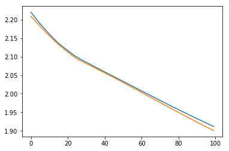

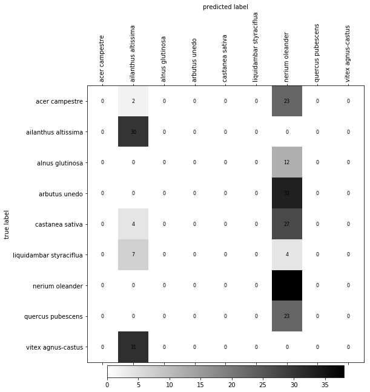

```python
# Start by setting the number of units in the hidden layer (to something small, < 5)
# and the number of epochs (20-200).
#----------------------------------------------------------------------------------
# N_NEURONS = 4
# N_LEARNING_RATE = 0.05
# N_MOMENTUM = 0.1
# N_EPOCH = 100

# See above

# Play with the learning rate (0.0-1.0) and momentum (0.0-1.0)
# and verify if the train and test errors decrease with the number of epochs
#----------------------------------------------------------------------------------
N_NEURONS = 4
N_EPOCH = 100

N_LEARNING_RATE = 0.01
N_MOMENTUM = 0.1

test_CNN(N_NEURONS,N_LEARNING_RATE,N_MOMENTUM,N_EPOCH)
```

```
Features =  7 , Outputs =  9
Neurons =  4 , learning rate =  1.0 , momentum =  0.1 , epoch =  100
                         precision    recall  f1-score   support

         acer campestre       0.00      0.00      0.00        25
    ailanthus altissima       0.20      1.00      0.33        30
        alnus glutinosa       0.00      0.00      0.00        12
          arbutus unedo       0.00      0.00      0.00        33
        castanea sativa       0.00      0.00      0.00        31
liquidambar styraciflua       0.00      0.00      0.00        11
        nerium oleander       0.00      0.00      0.00        38
      quercus pubescens       0.00      0.00      0.00        23
     vitex agnus-castus       0.37      1.00      0.54        31

            avg / total       0.07      0.26      0.11       234
```

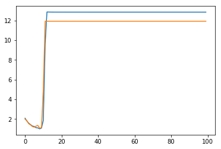

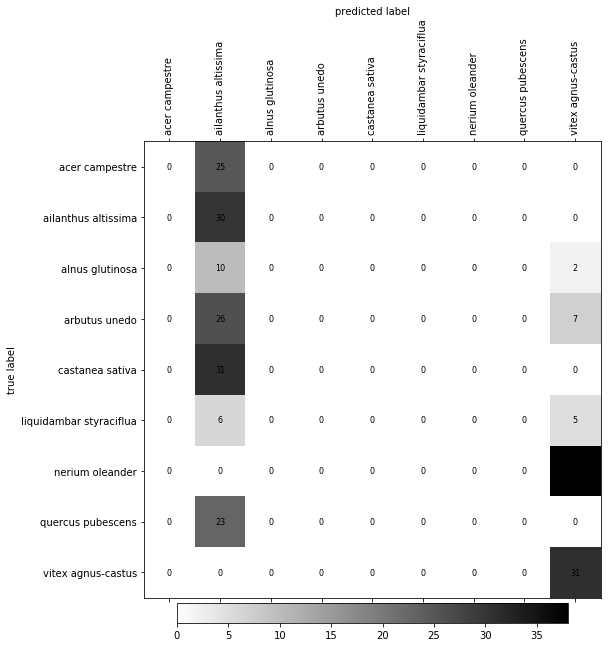

```python
N_NEURONS = 4
N_EPOCH = 100

N_LEARNING_RATE = 1.0
N_MOMENTUM = 0.1

test_CNN(N_NEURONS,N_LEARNING_RATE,N_MOMENTUM,N_EPOCH)
```

```
Features =  7 , Outputs =  9
Neurons =  4 , learning rate =  0.05 , momentum =  0.5 , epoch =  100
                         precision    recall  f1-score   support

         acer campestre       0.75      0.96      0.84        25
    ailanthus altissima       1.00      0.97      0.98        30
        alnus glutinosa       1.00      0.17      0.29        12
          arbutus unedo       0.75      0.91      0.82        33
        castanea sativa       1.00      0.48      0.65        31
liquidambar styraciflua       0.00      0.00      0.00        11
        nerium oleander       1.00      1.00      1.00        38
      quercus pubescens       0.53      1.00      0.70        23
     vitex agnus-castus       0.89      1.00      0.94        31

            avg / total       0.83      0.82      0.79       234
```

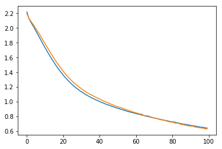

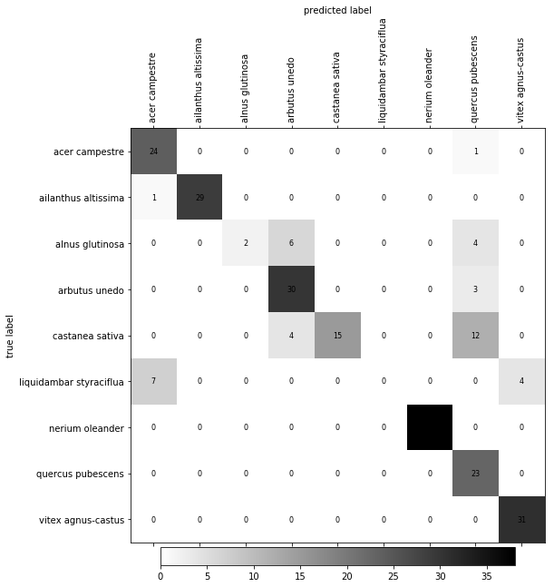

```python
N_NEURONS = 4
N_EPOCH = 100

N_LEARNING_RATE = 0.05
N_MOMENTUM = 0.5

test_CNN(N_NEURONS,N_LEARNING_RATE,N_MOMENTUM,N_EPOCH)
```

```
Features =  7 , Outputs =  9
Neurons =  4 , learning rate =  0.05 , momentum =  1.0 , epoch =  100
                         precision    recall  f1-score   support

         acer campestre       0.00      0.00      0.00        25
    ailanthus altissima       0.00      0.00      0.00        30
        alnus glutinosa       0.00      0.00      0.00        12
          arbutus unedo       0.00      0.00      0.00        33
        castanea sativa       0.00      0.00      0.00        31
liquidambar styraciflua       0.00      0.00      0.00        11
        nerium oleander       0.16      1.00      0.28        38
      quercus pubescens       0.00      0.00      0.00        23
     vitex agnus-castus       0.00      0.00      0.00        31

            avg / total       0.03      0.16      0.05       234
```

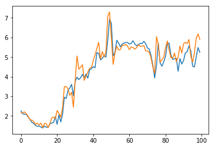

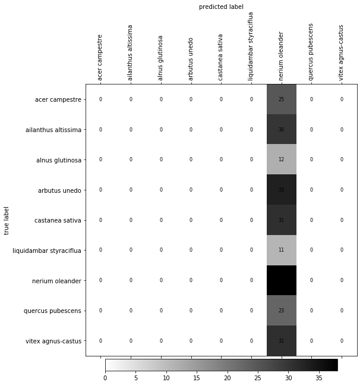

```python
N_NEURONS = 4
N_EPOCH = 100

N_LEARNING_RATE = 0.05
N_MOMENTUM = 1.0

test_CNN(N_NEURONS,N_LEARNING_RATE,N_MOMENTUM,N_EPOCH)
```

```
Features =  7 , Outputs =  9
Neurons =  2 , learning rate =  0.05 , momentum =  0.1 , epoch =  100
                         precision    recall  f1-score   support

         acer campestre       0.00      0.00      0.00        25
    ailanthus altissima       0.00      0.00      0.00        30
        alnus glutinosa       0.00      0.00      0.00        12
          arbutus unedo       0.19      0.42      0.26        33
        castanea sativa       0.00      0.00      0.00        31
liquidambar styraciflua       0.00      0.00      0.00        11
        nerium oleander       0.69      1.00      0.82        38
      quercus pubescens       0.21      0.96      0.34        23
     vitex agnus-castus       0.00      0.00      0.00        31

            avg / total       0.16      0.32      0.20       234
```

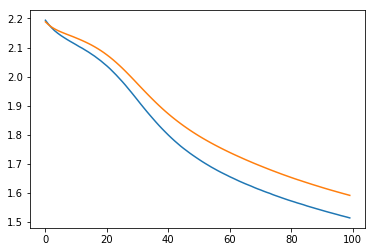

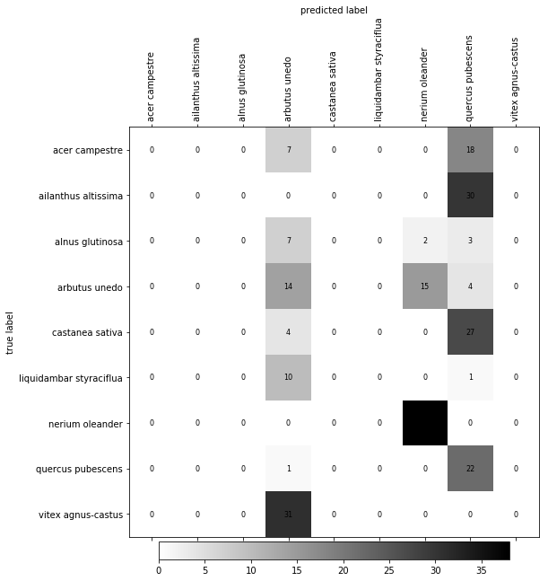

```python
# Once you have found good values for the learning rate and momentum,
# you can try modifying the number of epochs and the size of the hidden layer.
# On the one hand, you should choose a number of epochs so that the errors reaches a plateau,
# stopping the training when the error does not decrease anymore.
# On the other hand, you have to make your neural network sufficiently complex to obtain
# a good classification performance, while keeping it as simple as possible to avoid over-fitting.
#
# The classification performance will most likely be close to but lower than what
# you obtained with k-NN.
#------------------------------------------------------------------------------------------------
N_NEURONS = 2
N_EPOCH = 100

N_LEARNING_RATE = 0.05
N_MOMENTUM = 0.1

test_CNN(N_NEURONS,N_LEARNING_RATE,N_MOMENTUM,N_EPOCH)
```

```
Features =  7 , Outputs =  9
Neurons =  10 , learning rate =  0.05 , momentum =  0.1 , epoch =  100
                         precision    recall  f1-score   support

         acer campestre       0.77      0.96      0.86        25
    ailanthus altissima       1.00      1.00      1.00        30
        alnus glutinosa       0.00      0.00      0.00        12
          arbutus unedo       0.66      0.88      0.75        33
        castanea sativa       0.89      0.52      0.65        31
liquidambar styraciflua       0.00      0.00      0.00        11
        nerium oleander       1.00      1.00      1.00        38
      quercus pubescens       0.53      0.87      0.66        23
     vitex agnus-castus       0.89      1.00      0.94        31

            avg / total       0.75      0.80      0.76       234
```

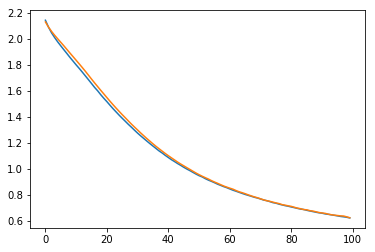

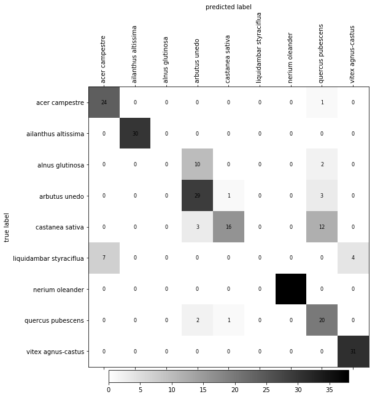

```python
N_NEURONS = 10
N_EPOCH = 100

N_LEARNING_RATE = 0.05
N_MOMENTUM = 0.1

test_CNN(N_NEURONS,N_LEARNING_RATE,N_MOMENTUM,N_EPOCH)
```

```
Features =  7 , Outputs =  9
Neurons =  4 , learning rate =  0.05 , momentum =  0.1 , epoch =  300
                         precision    recall  f1-score   support

         acer campestre       0.71      1.00      0.83        25
    ailanthus altissima       1.00      0.93      0.97        30
        alnus glutinosa       0.00      0.00      0.00        12
          arbutus unedo       0.83      0.91      0.87        33
        castanea sativa       0.81      0.68      0.74        31
liquidambar styraciflua       0.00      0.00      0.00        11
        nerium oleander       0.97      1.00      0.99        38
      quercus pubescens       0.62      0.91      0.74        23
     vitex agnus-castus       0.86      1.00      0.93        31

            avg / total       0.76      0.83      0.79       234
```

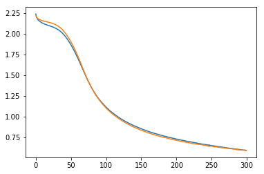

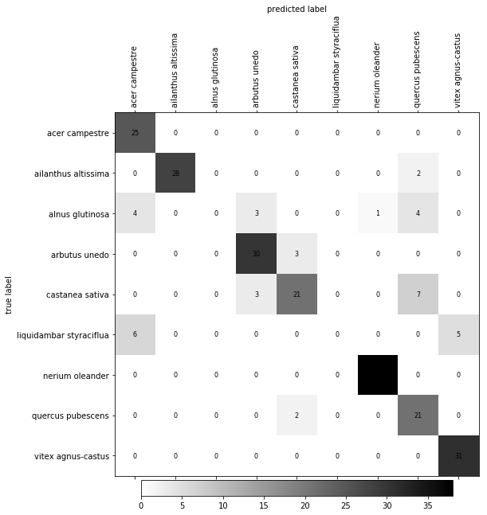

```python
N_NEURONS = 4
N_EPOCH = 300

N_LEARNING_RATE = 0.05
N_MOMENTUM = 0.1

test_CNN(N_NEURONS,N_LEARNING_RATE,N_MOMENTUM,N_EPOCH)
```

```
Features =  7 , Outputs =  9
Neurons =  4 , learning rate =  0.05 , momentum =  0.1 , epoch =  10
                         precision    recall  f1-score   support

         acer campestre       0.25      0.84      0.39        25
    ailanthus altissima       0.00      0.00      0.00        30
        alnus glutinosa       0.00      0.00      0.00        12
          arbutus unedo       0.00      0.00      0.00        33
        castanea sativa       0.00      0.00      0.00        31
liquidambar styraciflua       0.00      0.00      0.00        11
        nerium oleander       0.34      1.00      0.51        38
      quercus pubescens       0.00      0.00      0.00        23
     vitex agnus-castus       0.00      0.00      0.00        31

            avg / total       0.08      0.25      0.12       234
```

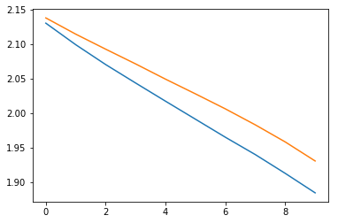

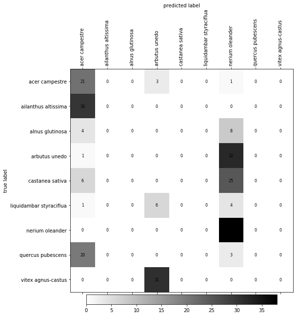

```python
N_NEURONS = 4
N_EPOCH = 10

N_LEARNING_RATE = 0.05
N_MOMENTUM = 0.1

test_CNN(N_NEURONS,N_LEARNING_RATE,N_MOMENTUM,N_EPOCH)
```

Q: Answer the following questions :

- How many output units are there in the network you trained ? Why ?
- How many parameters (weights and biases) are there in your network ? Why ?
  - hint: you can use *model.summary()* to get the topology of your network

```
Features =  7 , Outputs =  9
Neurons =  4 , learning rate =  0.05 , momentum =  0.1 , epoch =  100
                         precision    recall  f1-score   support

         acer campestre       0.50      0.28      0.36        25
    ailanthus altissima       0.74      0.67      0.70        30
        alnus glutinosa       0.00      0.00      0.00        12
          arbutus unedo       0.65      0.85      0.74        33
        castanea sativa       0.63      0.55      0.59        31
liquidambar styraciflua       0.00      0.00      0.00        11
        nerium oleander       1.00      1.00      1.00        38
      quercus pubescens       0.39      0.83      0.53        23
     vitex agnus-castus       0.86      1.00      0.93        31

            avg / total       0.64      0.68      0.65       234
```

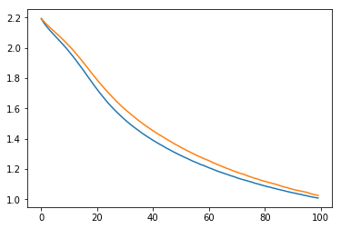

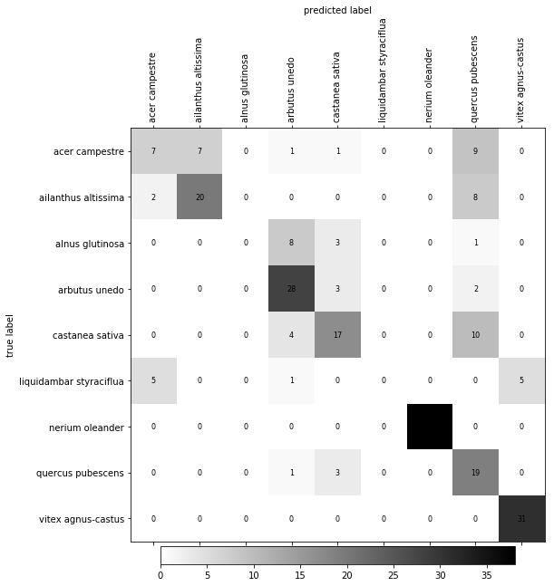

```python
#
# Fit your neural network model here
#

N_NEURONS = 4
N_LEARNING_RATE = 0.05
N_MOMENTUM = 0.1
N_EPOCH = 100

test_CNN(N_NEURONS,N_LEARNING_RATE,N_MOMENTUM,N_EPOCH)
```

```python
probabilities = model.predict(X_test, batch_size=32)

y_pred_nn = probabilities.argmax(axis=1)  # the highest output activation gives the class
y_test = Y_test.argmax(axis=1)
```

```python
report_nn = skmetrics.classification_report(y_test, y_pred_nn,
                                            labels=np.arange(len(lencoder.classes_)),
                                            target_names=lencoder.classes_)
confmat_nn = confusion_matrix(y_test, y_pred_nn)
```

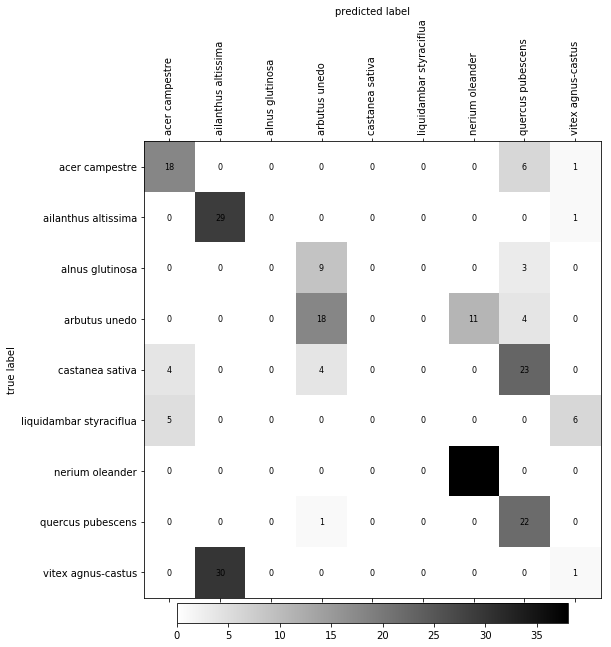

```python
pl.figure(figsize=(10, 10))
plot_confusion_matrix(confmat_nn, lencoder.classes_, cmap=cm.gray_r)
```

```python
print report_nn
```

```
                         precision    recall  f1-score   support

         acer campestre       0.67      0.72      0.69        25
    ailanthus altissima       0.49      0.97      0.65        30
        alnus glutinosa       0.00      0.00      0.00        12
          arbutus unedo       0.56      0.55      0.55        33
        castanea sativa       0.00      0.00      0.00        31
liquidambar styraciflua       0.00      0.00      0.00        11
        nerium oleander       0.78      1.00      0.87        38
      quercus pubescens       0.38      0.96      0.54        23
     vitex agnus-castus       0.11      0.03      0.05        31

            avg / total       0.39      0.54      0.44       234
```

```python
model.summary()
```

```
____________________________________________________________________________________________________
Layer (type)                     Output Shape          Param #     Connected to
====================================================================================================
input_5 (InputLayer)             (None, 7)             0
____________________________________________________________________________________________________
dense_9 (Dense)                  (None, 4)             32          input_5[0][0]
____________________________________________________________________________________________________
dense_10 (Dense)                 (None, 9)             45          dense_9[0][0]
====================================================================================================
Total params: 77
____________________________________________________________________________________________________
```